Your aim is to maintain a number of animals (individuals) of your choice, as well as the agricultural yield on the landscape.

As the manager, you make policy decisions on licences for farmers to hunt or scare the animals. Although you cannot affect the animal population directly, you can influence the decisions the farmers may make each year, by changing the cost of hunting or scaring licences.

[figure not shown]

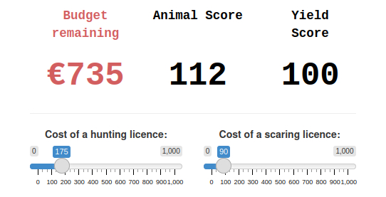

[figure not shown]

The higher you set the cost of either licence, the fewer of those actions are likely to be taken by each farmer.  
You have a fixed budget to allocate to setting the cost of each action; budget invested in one cannot be invested in the other.  
Leftover budgets are not rolled over to the next year.  
Note that you cannot directly change the cost of farming itself, but it is likely that more farming will happen if the costs of other actions are higher than the expected return of farming.

[figure not shown]

Icons made by monkik from [www.flaticon.com](https://www.flaticon.com/)